# Programming Assignment 3

Che Jung Lee - 301249826

## Data preprocessing

```r
training <- read.csv("./Titanic.Train.csv", colClasses = c("factor","factor","factor","numeric","numeric","numeric","numeric"))
test <- read.csv("./Titanic.Test.csv", colClasses = c("factor","factor","factor","numeric","numeric","numeric","numeric"))
set.seed(1)
```

## Task 1

```r
# train random forest model
rf.model <- randomForest(survived ~ ., data = training, ntree = 100, importance = TRUE)
# predict test data
rf.pred <- predict(rf.model, test)
# print the accuracy of the model
cat("accuracy of the random forest model:", mean(test$survived == rf.pred), "\n")
```

```
## accuracy of the random forest model: 0.8396947
```

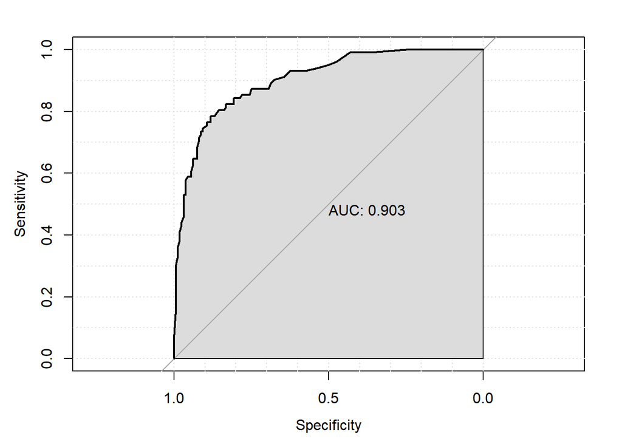

```r
# plot ROC curve
rf.pred <- predict(rf.model, test, type = "prob")
rf.roc <- roc(as.numeric(test$survived), rf.pred[, 1], plot = TRUE, grid = TRUE, print.auc = TRUE, auc.polygon = TRUE)
```

```r
cat("area under the curve:", rf.roc$auc, "\n")
```

```
## area under the curve: 0.9025735
```

As shown in the table below, the accuracy of the random forest model is higher than the decision tree model by 0.0648855, or 6.5%, which is a significant improvement.

| Model | Accuracy |
| --- | --- |
| decision tree | 0.7748092 |
| random forest | 0.8396947 |

## Task 2

```r
# get variable importance
rf.imp <- importance(rf.model)
# sort accuracy in decreasing order
rf.imp <- rf.imp[order(-rf.imp[, "MeanDecreaseAccuracy"]),]
# print variable importance
print(rf.imp)
```

```
##                0         1 MeanDecreaseAccuracy MeanDecreaseGini
## sex    33.592228 38.996308            46.218577        114.56179
## pclass 10.711533 16.495983            21.385650         38.66752
## age    12.722540 20.836544            20.529152         94.98805
## fare    4.808735 11.315226            13.743341         74.97770
## parch   5.650935  5.664085             9.217493         16.07289
## sibsp   7.772395  1.232700             7.949896         17.09923
```

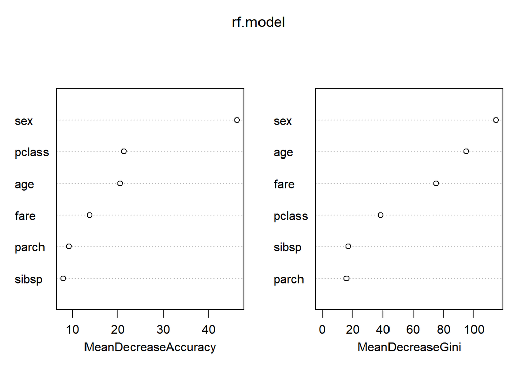

```r
# plot variable importance (type 1 = mean decrease in accuracy, 2 = mean decrease in node impurity)
varImpPlot(rf.model)
```

| Attribute | Reason |
| --- | --- |
| sex | this supports the idea of “women and children first”, which is a well known principle enforced by the captain of Titanic. |
| age | the same reason as above. |
| pclass | it is related to cabin, which is the room location on the ship. The higher the class, the higher the room, and thus the closer to deck and lifeboats. |

## Task 3

```r
# train glmnet model
glmnet.model <- train(survived ~ ., data = training, method = "glmnet", family = "binomial")
# print variable importance
print(varImp(glmnet.model))
```

```
## glmnet variable importance
##
##          Overall
## sexmale 100.0000
## pclass3  52.6575
## pclass2  11.5958
## sibsp     8.7797
## parch     1.8607
## age       0.9175
## fare      0.0000
```

Based on the *varImp* results, the most significant three attributes of the model are **sex**, **pclass**, and **sibsp** in decreasing order. Below is the reasoning of their relevance for the classification task:

| Attribute | Reason |
| --- | --- |
| sex | this supports the idea of “women and children first”, which is a well known principle enforced by the captain of Titanic. |
| pclass | it is related to cabin, which is the room location on the ship. The higher the class, the higher the room, and thus the closer to deck and lifeboats. |
| sibsp | it is related to family size. The lower the sibsp, the lesser the family members that one needs to take care of. |

## Task 4

```r
# predict test data
glmnet.pred <- predict(glmnet.model, test)

# print confusion matrix and accuracy
print("confusion matrix of the glmnet model:")
```

```
## [1] "confusion matrix of the glmnet model:"
```

```r
print(table(test$survived, glmnet.pred))
```

```
##    glmnet.pred
##       0   1
##   0 141  19
##   1  32  70
```

```r
cat("accuracy of the glmnet model:", mean(test$survived == glmnet.pred), "\n")
```

```
## accuracy of the glmnet model: 0.8053435
```

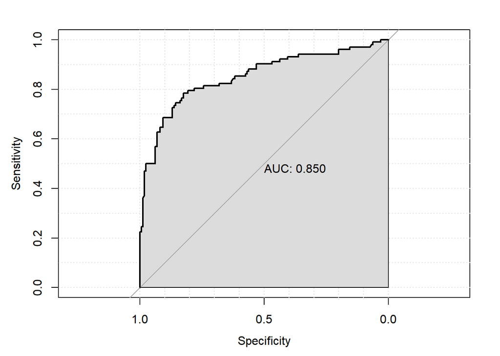

```r
# plot ROC curve
glmnet.pred <- predict(glmnet.model, test, type = "prob")
glmnet.roc <- roc(as.numeric(test$survived), glmnet.pred[, 1], plot = TRUE, grid = TRUE, print.auc = TRUE, auc.polygon = TRUE)
```

```r
cat("area under the curve:", glmnet.roc$auc, "\n")
```

```
## area under the curve: 0.8503983
```

## Task 5

```r
# tune svm models
svm.linear.tune <- tune.svm(survived ~ ., data = training, kernel = "linear", cost=10^(-3:2), probability = TRUE)
svm.radial.tune <- tune.svm(survived ~ ., data = training, kernel = "radial", cost=10^(-3:2), gamma=seq(.01, .1, by=0.01), probability = TRUE)
print("best parameters for the linear kernel:")
```

```
## [1] "best parameters for the linear kernel:"
```

```r
print(svm.linear.tune$best.parameters)
```

```
##   cost
## 2 0.01
```

```r
print("best parameters for the radial kernel:")
```

```
## [1] "best parameters for the radial kernel:"
```

```r
print(svm.radial.tune$best.parameters)
```

```
##    gamma cost
## 46  0.06   10
```

The best parameter for the linear kernel is $cost = 0.01$, where $cost$ denotes the penalty of misclassification. The higher the $cost$, the higher the penalty, resulting in a smaller margin separating hyperplane and lower misclassifications in the training data set. Conversely, the lower the $cost$, the lower the penalty, leading to a larger margin separating hyperplane and higher misclassifications. The former may cause overfitting and the latter may cause underfitting; the best one depends on the structure of the future data. In this case, low $cost$ value is the best.

The best parameters for the radial kernel are $cost = 10$ and $gamma = 0.06$, where $gamma$ denotes the sensitivity to differences in feature spaces. The higher the $gamma$, the higher the sensitivity, resulting in higher influence of individual points and narrower decision boundary. Conversely, the lower the $gamma$, the lower the sensitivity, leading to lower influence of individual points and broader decision boundary. Again, the former may cause overfitting and the latter may cause underfitting; the best one depends on the structure of the future data. In this case, the configuration of high $cost$ and low $gamma$ yields the best performance.

Note that $gamma$ is a parameter of the radial basis function (aka gaussian) kernel; thus it makes no sense to tune it in the linear kernel model.

## Task 6

```r
# predict test data using the best models
svm.linear.pred <- predict(svm.linear.tune$best.model, test, probability = TRUE)
svm.radial.pred <- predict(svm.radial.tune$best.model, test, probability = TRUE)

# print accuracy
cat("accuracy of the tuned linear svm model:", mean(test$survived == svm.linear.pred), "\n")
```

```
## accuracy of the tuned linear svm model: 0.8091603
```

```r
cat("accuracy of the tuned radial svm model:", mean(test$survived == svm.radial.pred), "\n")
```

```
## accuracy of the tuned radial svm model: 0.8244275
```

```r
# plot ROC curve
print("ROC curve of the linear svm model:")
```

```
## [1] "ROC curve of the linear svm model:"
```

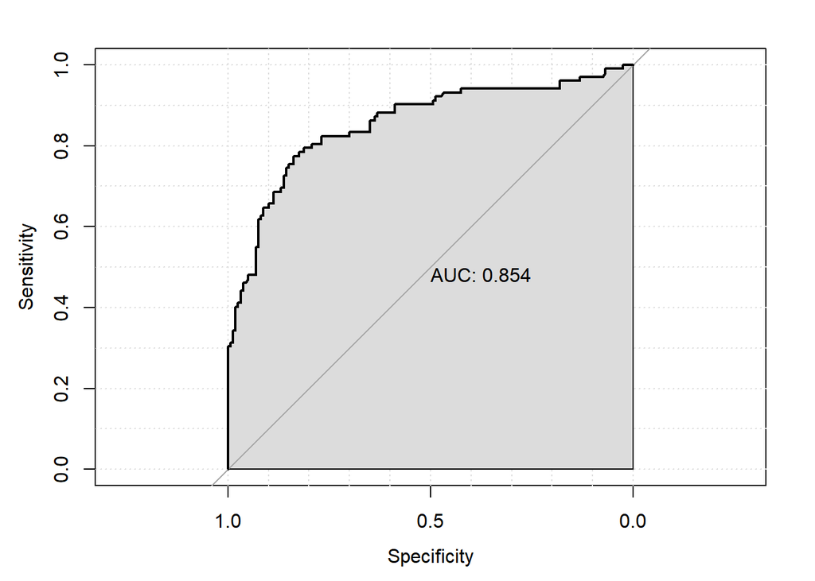

```r
svm.linear.roc <- roc(as.numeric(test$survived), attr(svm.linear.pred, "probabilities")[, 1], plot = TRUE, grid = TRUE, print.auc = TRUE, auc.polygon = TRUE)
```

```r
cat("area under the curve:", svm.linear.roc$auc, "\n")
```

```
## area under the curve: 0.8543811
```

```r
print("ROC curve of the radial svm model:")
```

```
## [1] "ROC curve of the radial svm model:"
```

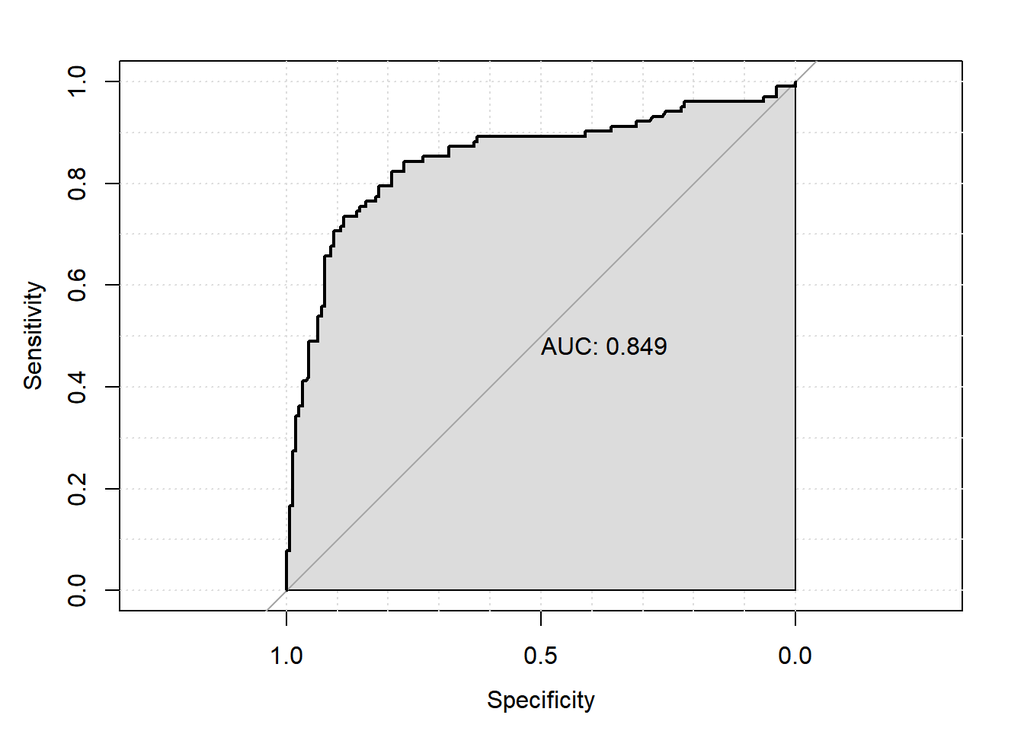

```r
svm.radial.roc <- roc(as.numeric(test$survived), attr(svm.radial.pred, "probabilities")[, 1], plot = TRUE, grid = TRUE, print.auc = TRUE, auc.polygon = TRUE)
```

```r
cat("area under the curve:", svm.radial.roc$auc, "\n")
```

```
## area under the curve: 0.8494179
```